# Propiedades de la población

## 2.3 Datos ambientales

### 2.3.1 Datos raster

Los modelos de distribución de especies necesitan, por un lado, los puntos de presencia que acabamos de limpiar y los datos de ausencia que generamos, pero además, necesitamos variables que expliquen esa distribución (variables explicativas). Generalmente las variables explicativas son variables climáticas, geomorfológicas entre otras (clima, suelo, terreno, vegetación, uso del suelo, etc.)

Las variables explicativas generalmente se organizan como archivos de tipo raster (cuadrícula), de tal forma que tendremos tantos raster como variable explicativa a ser usada. Estos datos generalmente se almacenan en archivos en algún tipo de formato SIG. Se pueden utilizar casi todos los formatos relevantes (incluida la cuadrícula ESRI, geoTiff, netCDF, IDRISI). Los archivos ASCII pueden ser usados aunque estos tienden a reducir considerablemente la velocidad de procesamiento. Para cualquier estudio en particular, todas las capas deben tener la misma extensión espacial, resolución, origen y proyección. Si es necesario, use funciones como *crop*, *extend*, *aggregate*, *resample* y *projectRaster* desde el paquete **raster**.

El paquete **dismo** trae cargadas varias variables provenientes de la base de datos de WorldClim (Hijmans et al., 2004) y los datos de biomas terrestres de la WWF (Olsen et al., 2001). A continuación desarrollemos los pasos para extraer los datos del paquete dismo y empaquetarlos en un stack que nos permita procesar en conjunto todas las variables.

```r
#Definimos el directorio donde están los archivos
path <- file.path(system.file(package="dismo"), 'ex')
#obtenemos un listado de las variables tipo grd (grid) que están en dismo
#grd$ nos permite obtener todos las variables grid
library(dismo)
files <- list.files(path, pattern='grd$', full.names=TRUE )
files
```

```
## [1] "C:/Users/ciesp/Documents/R/win-library/3.5/dismo/ex/bio1.grd"
## [2] "C:/Users/ciesp/Documents/R/win-library/3.5/dismo/ex/bio12.grd"
## [3] "C:/Users/ciesp/Documents/R/win-library/3.5/dismo/ex/bio16.grd"
## [4] "C:/Users/ciesp/Documents/R/win-library/3.5/dismo/ex/bio17.grd"
## [5] "C:/Users/ciesp/Documents/R/win-library/3.5/dismo/ex/bio5.grd"
## [6] "C:/Users/ciesp/Documents/R/win-library/3.5/dismo/ex/bio6.grd"
## [7] "C:/Users/ciesp/Documents/R/win-library/3.5/dismo/ex/bio7.grd"
## [8] "C:/Users/ciesp/Documents/R/win-library/3.5/dismo/ex/bio8.grd"
## [9] "C:/Users/ciesp/Documents/R/win-library/3.5/dismo/ex/biome.grd"
```

```r
#empaquetamos las variables en un stack
predictors <- stack(files)
predictors
```

```
## class      : RasterStack
## dimensions : 192, 186, 35712, 9  (nrow, ncol, ncell, nlayers)
## resolution : 0.5, 0.5  (x, y)
## extent     : -125, -32, -56, 40  (xmin, xmax, ymin, ymax)
## crs        : +proj=longlat +datum=WGS84 +ellps=WGS84 +towgs84=0,0,0
## names      : bio1, bio12, bio16, bio17, bio5, bio6, bio7, bio8, biome
## min values :  -23,     0,     0,     0,   61, -212,   60,  -66,     1
## max values :  289,  7682,  2458,  1496,  422,  242,  461,  323,    14
```

```r
names(predictors)
```

```
## [1] "bio1"  "bio12" "bio16" "bio17" "bio5"  "bio6"  "bio7"  "bio8"  "biome"
```

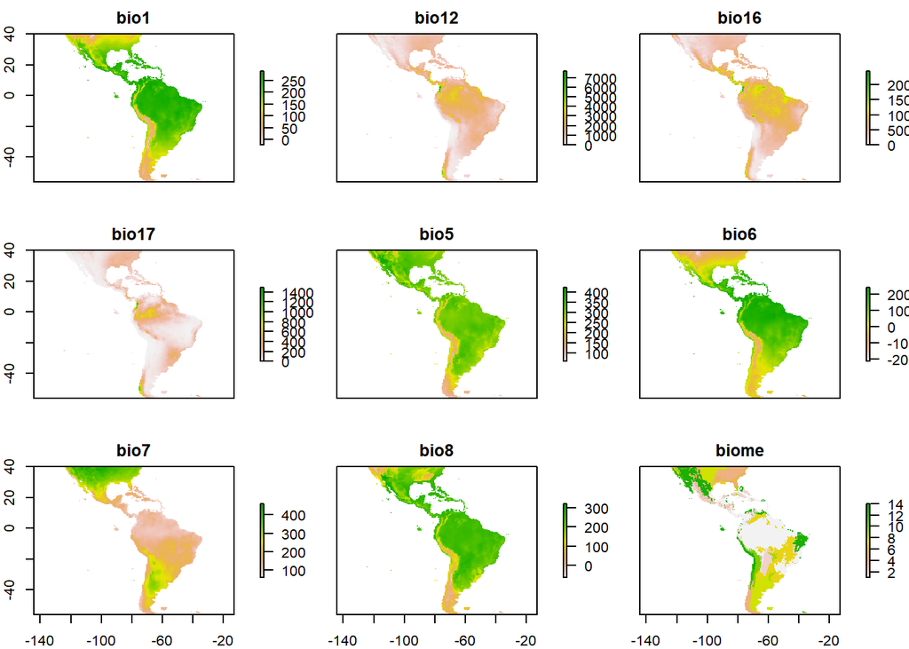

```r
plot(predictors)
```

Vamos a graficar una de las variables y sobreponer los datos geopolíticos e incluir los datos de Desmodus que hemos limpiado.

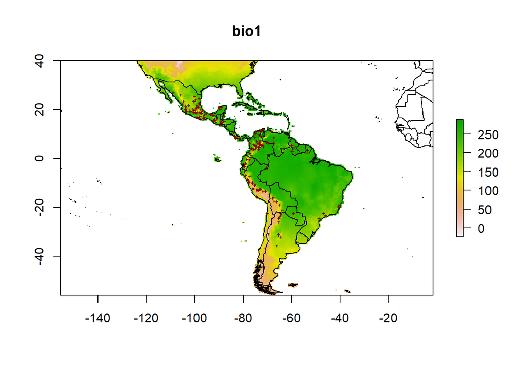

```r
library(maptools)
#generamos un objeto tipo SpatialPoint
desFD <- desmodFD
coordinates(desFD) <- ~lon+lat
projection(desFD) <- CRS('+proj=longlat +datum=WGS84')

# Graficamos la primera variable climática
plot(predictors, 1)
# Adicionamos los límites políticos
#usamos add=TRUE para que se sobreponga sobre el gráfico anterior
plot(wrld_simpl, add=TRUE)
#finalmente adicionamos los datos de Desmodus
points(desFD, col="darkred", pch=3, cex=0.3)
```

Obtener las variables explicativas es un paso muy importante, sobre todo si nuestro enfoque es predictivo y no explicativo. El modelado de distribución geográfica no busca comprender el efecto de las variables explicativas, sino más bien nos interesa tener capacidad para predecir la distribución. De esta forma, es vital tener variables que permitan realizar la predicción, para lo cual es importante conocer la ecología de la especie. Variables que son importantes para una especie pueden ser irrelevantes para otras, ej. una variable de suelo puede ser muy importante para una planta, pero irrelevante para un ave. En el proceso de modelado necesitamos contar con variables relevantes para la especie que estamos modelando.

### 2.3.2 Extrayendo los datos ambientales

Ahora que tenemos tanto nuestras variables de presencia-ausencia como nuestras variables explicativas, el siguiente paso es extraer los valores de las variables explicativas. Cada punto de ocurrencia y ausencia le corresponde un valor de cada variable explicativa. Usaremos la función *extract* del paquete **raster** para obtener los valores de las variables contenidas en el stack, usaremos tanto los datos de ocurrencia que limpiamos como los datos de fondo que generamos.

```r
#extraemos los valores
presvals <- extract(predictors, desFD) #presencias
absvals <- extract(predictors, bg) #datos de fondo
seabsvals <- extract(predictors, xyInside) #pseudo-ausencias

#generamos una variable de presencia ausencia
pb <- c(rep(1, nrow(presvals)), rep(0, nrow(absvals)))

#unimos los datos de presencia-ausencia y la juntamos con la variable
#que acabamos de generar
sdmdata <- data.frame(cbind(pb, rbind(presvals, absvals)))
#convertimos en factor la variable biome
sdmdata[,'biome'] = as.factor(sdmdata[,'biome'])
head(sdmdata)
```

```
##   pb bio1 bio12 bio16 bio17 bio5 bio6 bio7 bio8 biome
## 1  1  245  1042   503    77  336  138  199  276     1
## 2  1  202  2500   811   363  261  149  112  198     1
## 3  1  208  1471   654   162  289  121  168  225     1
## 4  1  255  3416  1491   194  330  190  139  248     1
## 5  1  131   846   452    47  229   21  208  135     1
## 6  1  233   679   286    77  356   84  272  276    13
```

Ahora evaluamos las variables que están correlacionadas, es necesario que dentro del modelo evitemos usar variables que muestren colinearidad espacial. Para ello realizamos correlaciones entre variables para determinar que variables están asociadas y poder decidir que variables usar en el modelo.

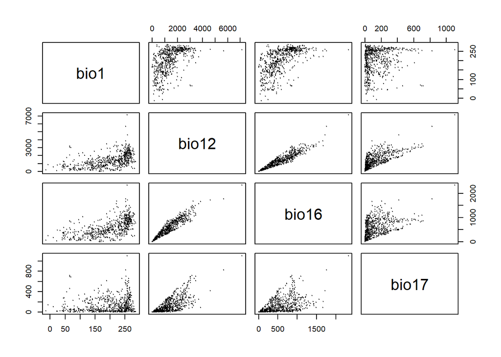

```r
pairs(sdmdata[,2:5], cex=0.1)
```

Como podemos observar las variables bio12 y bio16 están fuertemente correlacionadas. Por ahora nos quedaremos con las variables que hemos logrado obtener. Por ahora grabamos los datos para que estén disponibles para los siguientes análisis.

```r
saveRDS(sdmdata, "sdm.Rds")
saveRDS(presvals, "pvals.Rds")
```

## 2.4 Ajuste del modelo, predicción y evaluación

### 2.4.1 Ajuste de un modelo

Ajustar un SDM (modelo espacial) es técnicamente similar a otras técnicas de modelado. Lo que haremos es identificar las variables dependientes en independientes. De esta forma la variable dependiente presencias-ausencias en relación a las variables ambientales. Vamos a ajustar un modelo lineal generalizado con los datos que hemos levantado.

```r
#leemos los datos
library(dismo)
sdmdata <- readRDS("sdm.Rds")
presvals <- readRDS("pvals.Rds")

#Usamos unas pocas variables
m1 <- glm(pb ~ bio1 + bio5 + bio12, data=sdmdata)
summary(m1)
```

```
##
## Call:
## glm(formula = pb ~ bio1 + bio5 + bio12, data = sdmdata)
##
## Deviance Residuals:
##     Min       1Q   Median       3Q      Max
## -0.5542  -0.2808  -0.2012   0.4465   0.9337
##
## Coefficients:
##               Estimate Std. Error t value Pr(>|t|)
## (Intercept)  8.900e-01  1.002e-01   8.884  < 2e-16 ***
## bio1         2.141e-03  5.023e-04   4.263 2.31e-05 ***
## bio5        -3.394e-03  5.066e-04  -6.700 4.44e-11 ***
## bio12       -3.420e-05  2.431e-05  -1.407     0.16
## ---
## Signif. codes:  0 '***' 0.001 '**' 0.01 '*' 0.05 '.' 0.1 ' ' 1
##
## (Dispersion parameter for gaussian family taken to be 0.1774249)
##
##     Null deviance: 126.87  on 669  degrees of freedom
## Residual deviance: 118.16  on 666  degrees of freedom
## AIC: 748.8
##
## Number of Fisher Scoring iterations: 2
```

Ahora tenemos nuestro modelo, pero como habíamos dicho, no nos interesa saber si estas variables afectan significativamente la presencia de especies, sino poder realizar predicciones a partir de este modelo.

### 2.4.2 Predicciones

Usaremos el modelo para predecir la probabilidad de ocurrencia de esta especie en unas zonas con diferentes condiciones ambientales. Usaremos la función *predict* para proyectar la probabilidad de ocurrencia.

```r
#generamos unos valores para cada una de las
#variables usadas en el modelo

bio1 = c(40, 150, 200)
bio5 = c(60, 115, 290)
bio12 = c(600, 1600, 1700)

#Las unimos en un data.frame
pd = data.frame(cbind(bio1, bio5, bio12))
pd
```

```
##   bio1 bio5 bio12
## 1   40   60   600
## 2  150  115  1600
## 3  200  290  1700
```

```r
#predecimos la probabilidad de ocurrencia en esos sitios
predict(m1, pd)
```

```
##         1         2         3
## 0.7514777 0.7661183 0.2757831
```

Como vemos la probabilidad de ocurrencia en los sitios 1 y 2 son mayores al sitio 3. Pero, ¿Cómo las variables influencian la ocurrencia? Podemos utilizar la función *response* para ver cómo cada una de estas variables determina la ocurrencia.

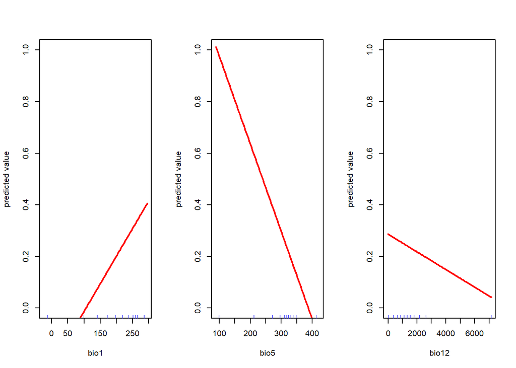

```r
response(m1)
```

Como vemos bio5 tiene un efecto más fuerte sobre la probabilidad de ocurrencia de la especie.

Ahora, como lo que nos interesa que las probabilidades de ocurrencia se muestren en el espacio, utilizaremos el paquete **raster** y la función predict para espacializar el modelo.

```r
# Extraemos las variables
predictors <- stack(list.files(file.path(system.file(package="dismo"), 'ex'), pattern='grd$', full.names=TRUE ))
names(predictors)
```

```
## [1] "bio1"  "bio12" "bio16" "bio17" "bio5"  "bio6"  "bio7"  "bio8"  "biome"
```

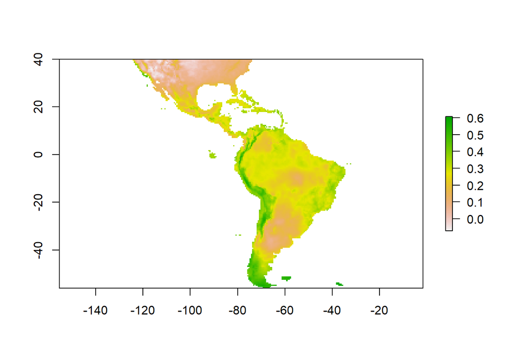

```r
#realizamos la predicción en base al modelo 1
p <- predict(predictors, m1)
#graficamos
plot(p)
```

### 2.4.3 Evaluación del modelo

Como vemos resulta ser bastante sencillo, hacer un modelo y mostrarlo en el espacio. Sin embargo, lo que nos interesa es saber si este modelo predice efectivamente la ocurrencia de las especies. Existen muchas formas de evaluar el ajuste de un modelo y estas son dependientes del modelo que se esté usando. Uno de los métodos más utilizados para realizar una evaluación de los SDM es la validación cruzada (cross-validation).

La validación cruzada consiste en crear un modelo con un conjunto de datos de “entrenamiento” y probarlo con otro conjunto de datos de ocurrencias conocidas, datos de “prueba”. Por lo general, los datos de entrenamiento y prueba se crean muestreando aleatoriamente (sin reemplazo) el conjunto de datos que hemos logrado recabar.

Se pueden usar diferentes medidas para evaluar la calidad de una predicción (Fielding y Bell, 1997, Liu et al., 2011; y Potts, para datos de presencia y Elith 2006 para datos de abundancia), dependiendo del objetivo del estudio. Muchas medidas para evaluar modelos basadas en datos de presencia-ausencia son “dependientes del umbral”. Eso significa que primero se debe establecer un umbral sobre el cual se considera que la especie ocurre (por ejemplo, 0.5, aunque 0.5 rara vez es una opción sensata, por ejemplo, ver Lui et al. 2005). Los valores pronosticados por encima de ese umbral indican una predicción de “presencia”, y los valores por debajo del umbral indican “ausencia”.

Las estadísticas más utilizadas, que son independientes del umbral son el coeficiente de correlación y el área bajo la curva del operador receptor (AUROC, generalmente abreviado como AUC). AUC es una medida de correlación de rango. En datos imparciales, un AUC alto indica que los sitios con valores de aptitud predichos altos tienden a ser áreas de presencia conocida y las ubicaciones con valores de predicción modelo más bajos tienden a ser áreas donde no se sabe que la especie esté presente (ausente o un punto aleatorio). Un puntaje de AUC de 0.5 significa que el modelo es tan bueno como una suposición aleatoria. Ver Phillips et al. (2006) para una discusión sobre el uso de AUC en el contexto de datos de solo presencia en lugar de datos de presencia / ausencia. Normalmente, modelos por arriba de 0.75 de AUC son modelos considerados aceptables.

Para ejemplificar, vamos a realizar un modelo usando Bioclim un modelo que usa solo datos de presencia.

```r
#sacamos el 75% de los datos para entrenamiento
samp <- sample(nrow(sdmdata), round(0.75 * nrow(sdmdata)))
traindata <- sdmdata[samp,]

#Eliminamos las ausencias
traindata <- traindata[traindata[,1] == 1, 2:9]

#El 25% restante queda como datos de prueba
testdata <- sdmdata[-samp,]

#Hacemos el modelo con datos de entrenamiento
bc <- bioclim(traindata)

#evaluamos presencias y ausencias
e <- evaluate(testdata[testdata==1,], testdata[testdata==0,], bc)
e
```

```
## class          : ModelEvaluation
## n presences    : 41
## n absences     : 127
## AUC            : 0.6497983
## cor            : 0.1867107
## max TPR+TNR at : 0.04641163
```

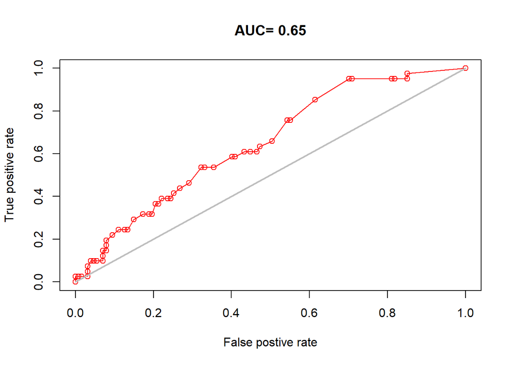

```r
#Graficamos el resultado
plot(e, 'ROC')
```

## 2.5 Métodos de modelamiento

### 2.5.1 Tipos de algoritmos usados

Una gran cantidad de algoritmos han sido utilizados para desarrollar SDM. Estos algoritmos pueden ser clasificados en tres tipos; i) envuelta, ii) regresión y iii) aprendizaje automático (Machine learning). Los algoritmos de envuelta consideran solamente los datos de presencia. Los otros dos tipos de algoritmos usan datos de presencia y ausencia.

Vamos a utilizar datos de una especie del *Desmodus rotundus* que hemos limpiado. Además, extraeremos los datos de las variables independientes que usaremos y, finalmente, dividiremos los datos en entrenamiento y validación.

```r
library(dismo)
library(maptools)
data(wrld_simpl)

#extraemos los datos bioclimáticos
predictors <- stack(list.files(file.path(system.file(package="dismo"), 'ex'), pattern='grd$', full.names=TRUE ))

#obtenemos los datos de cada predictor para nuestros datos de presencia
presvals <- extract(predictors, desFD)
set.seed(0)

#Generamos datos de fondo
backgr <- randomPoints(predictors, 500)

#Extraemos los datos de cada predictor de los datos de fondo
absvals <- extract(predictors, backgr)

#Generamos un vector de presencia ausencia
pb <- c(rep(1, nrow(presvals)), rep(0, nrow(absvals)))

#Unimos todo
sdmdata <- data.frame(cbind(pb, rbind(presvals, absvals)))
sdmdata[,'biome'] <- as.factor(sdmdata[,'biome'])
```

Debido a que algunos algoritmos no admiten variables categóricas eliminaremos del stack la variable de bioma.

```r
pred_nf <- dropLayer(predictors, 'biome')
```

Ahora dividimos los datos en entrenamiento y prueba.

```r
set.seed(0)

#generamos 5 grupos aleatorios
group <- kfold(desmodFD, 5)

#Escogemos un grupo de prueba y el resto de entrenamiento
pres_train <- desmodFD[group != 1, ]
pres_test <- desmodFD[group == 1, ]

#Restringimos la predicción
ext <- extent(-110, -32, -33, 30)
```

```r
#Generamos los datos de fondo
set.seed(10)
backg <- randomPoints(pred_nf, n=1000, ext=ext, extf = -1.25)
colnames(backg) <- c('lon', 'lat')
group <- kfold(backg, 5)

#separamos datos de entrenamiento y prueba
backg_train <- backg[group != 1, ]
backg_test <- backg[group == 1, ]
```

Ahora graficamos la información que hemos obtenido para confirmar que todo esté bien. Usaremos uno de los predictores como marco de la figura.

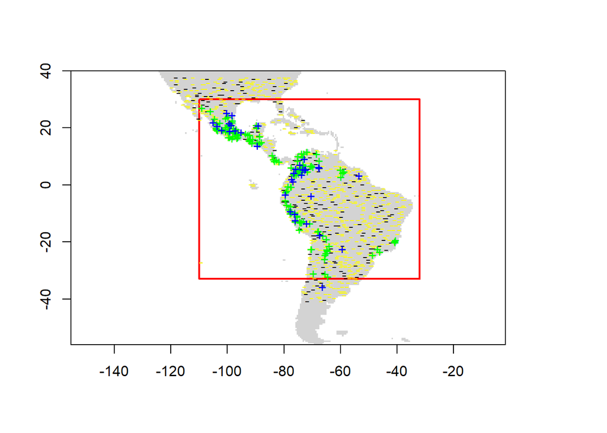

```r
#Extraemos los datos del raster
r <- raster(pred_nf, 1)

#Graficamos el raster
plot(!is.na(r), col=c('white', 'light grey'), legend=FALSE)

#graficamos la ventana
plot(ext, add=TRUE, col='red', lwd=2)
#graficamos los puntos de fondo
points(backg_train, pch='-', cex=0.9, col='yellow')
points(backg_test, pch='-',  cex=0.9, col='black')
#graficamos los puntos de ocurrencia
points(pres_train$lon, pres_train$lat, pch= '+', col='green')
points(pres_test$lon, pres_test$lat, pch='+', col='blue')
```

Al parecer todo está donde debería estar, ahora podemos ajustar los diferentes modelos utilizando la información que hemos preparado.

### 2.5.2 Algoritmos de Envuelta

A continuación vamos a usar tres diferentes algoritmos para realizar nuestros modelos; BIOCLIM, DOMAIN y distancia de MAHALANOBIS. Como lo mencionamos anteriormente estos algoritmos usan únicamente los datos de presencia. Aunque estos modelos han sido ampliamente utilizados, según algunos autores, estos modelos son menos efectivos que otros, particularmente cuando son utilizados para evaluar cambio climático. El algoritmo BIOCLIM calcula la similitud de una ubicación comparando los valores de las variables ambientales en cualquier ubicación con una distribución porcentual de los valores en ubicaciones conocidas de ocurrencia (“sitios de entrenamiento”).

```r
#Ajustamos el algoritmo a nuestros datos
bc <- bioclim(pred_nf, pres_train[,c("lon","lat")])
#evaluamos el modelo
e <- evaluate(pres_test[,c("lon","lat")], backg_test[,c("lon","lat")], bc, pred_nf)
e
```

```
## class          : ModelEvaluation
## n presences    : 34
## n absences     : 200
## AUC            : 0.6017647
## cor            : 0.04966259
## max TPR+TNR at : 0.05872353
```

```r
#Definimos a que nivel se realizará el corte de presencia-ausencia
tr <- threshold(e, 'spec_sens')
tr
```

```
## [1] 0.05872353
```

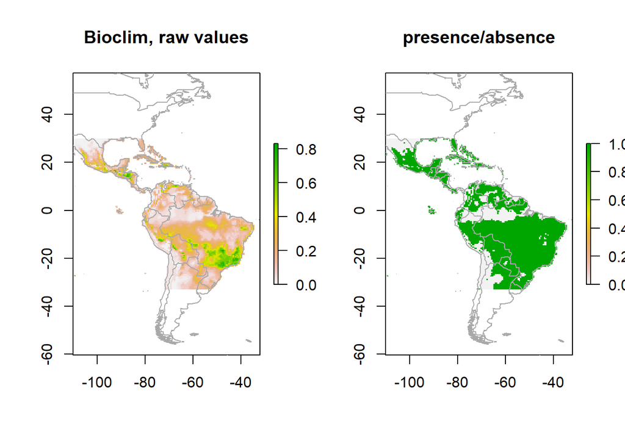

```r
#Extrapolamos los datos a un área de interés
pb <- predict(pred_nf, bc, ext=ext, progress='')

#graficamos el modelo
par(mfrow=c(1,2))
plot(pb, main='Bioclim, raw values')
plot(wrld_simpl, add=TRUE, border='dark grey')
plot(pb > tr, main='presence/absence')
plot(wrld_simpl, add=TRUE, border='dark grey')
points(pres_train, pch='+')
```

El algoritmo de Domain (Carpenter et al. 1993) calcula la distancia de Gower entre las variables ambientales en cualquier ubicación y de estas en las ubicaciones de ocurrencia (“sitios de entrenamiento”). A continuación, ajustamos un modelo de dominio, lo evaluamos y hacemos una predicción. Mapeamos la predicción, así como un mapa clasificado subjetivamente en presencia / ausencia.

```r
#generamos el modelo
dm <- domain(pred_nf, pres_train[,c("lon","lat")])

#lo evaluamos
e <- evaluate(pres_test[,c("lon","lat")], backg_test, dm, pred_nf)
e
```

```
## class          : ModelEvaluation
## n presences    : 34
## n absences     : 200
## AUC            : 0.5425
## cor            : 0.1253585
## max TPR+TNR at : 0.4919958
```

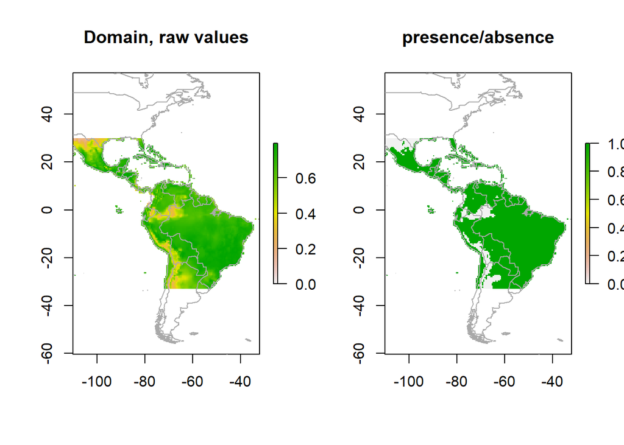

```r
#predecimos en el espacio
pd = predict(pred_nf, dm, ext=ext, progress='')

#graficamos el modelo
par(mfrow=c(1,2))
plot(pd, main='Domain, raw values')
plot(wrld_simpl, add=TRUE, border='dark grey')
tr <- threshold(e, 'spec_sens')
plot(pd > tr, main='presence/absence')
plot(wrld_simpl, add=TRUE, border='dark grey')
points(pres_train, pch='+')
```

Finalmente ajustamos el algoritmo Malahanobis. La función *mahal* implementa un modelo de distribución de especies basado en la distancia de Mahalanobis (Mahalanobis, 1936). La distancia de Mahalanobis tiene en cuenta las correlaciones de las variables en el conjunto de datos, y no depende de la escala de mediciones.

```r
#Ajustamos el modelo
mm <- mahal(pred_nf, pres_train[,c("lon","lat")])

#lo evaluamos
em <- evaluate(pres_test[,c("lon","lat")], backg_test, mm, pred_nf)
em
```

```
## class          : ModelEvaluation
## n presences    : 34
## n absences     : 200
## AUC            : 0.7479412
## cor            : 0.1532754
## max TPR+TNR at : -1.133013
```

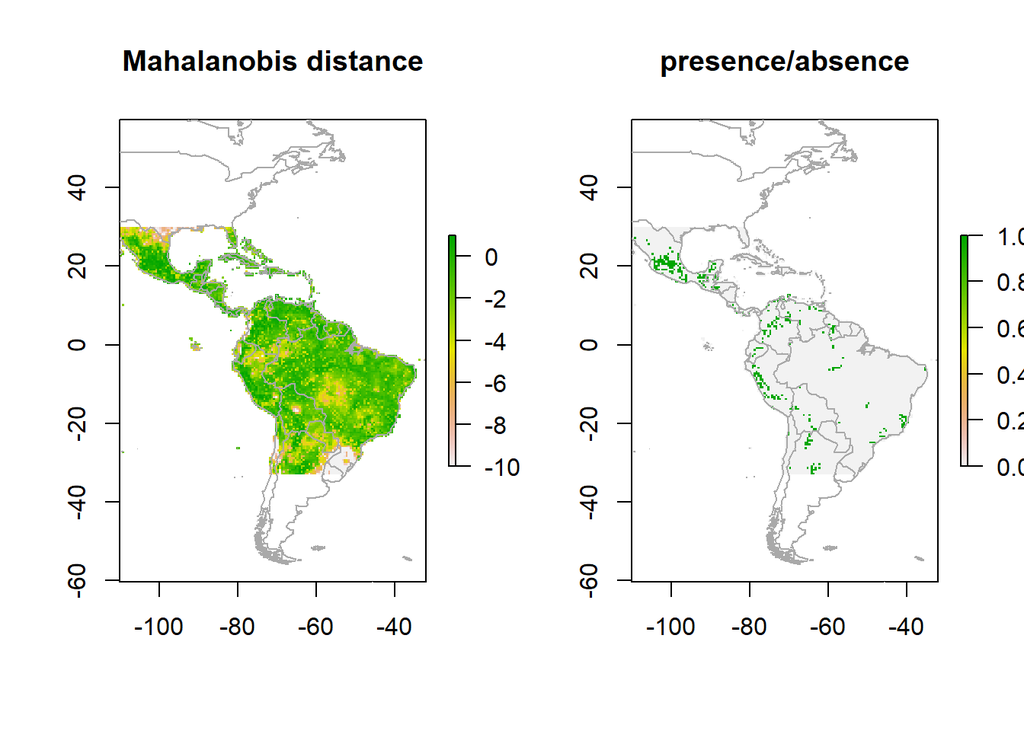

```r
#predecimos
pm = predict(pred_nf, mm, ext=ext, progress='')

#Los graficamos
par(mfrow=c(1,2))
pm[pm < -10] <- -10
plot(pm, main='Mahalanobis distance')
plot(wrld_simpl, add=TRUE, border='dark grey')
tr <- threshold(e, 'spec_sens')
plot(pm > tr, main='presence/absence')
plot(wrld_simpl, add=TRUE, border='dark grey')
points(pres_train, pch='+')
```

### 2.5.3 Modelos de regresiones

Los modelos de regresiones se ajustan a los datos de presencia y ausencia (fondo). No podemos ajustar el modelo con un RasterStack y puntos. Lo que haremos es extraer los valores de los datos ambientales y ajustar los modelos con estos valores.

```r
#pegamos los datos de presencia y ausencia
#Las coordenadas
train <- rbind(pres_train[,c("lon","lat")], backg_train[,c("lon","lat")])
#la variable de ocurrencia
pb_train <- c(rep(1, nrow(pres_train)), rep(0, nrow(backg_train)))

#Extraemos los datos ambientales de entrenamiento
envtrain <- extract(predictors, train)
envtrain <- data.frame( cbind(pa=pb_train, envtrain) )
envtrain[,'biome'] = factor(envtrain[,'biome'], levels=1:14)
head(envtrain)
```

```
##   pa bio1 bio12 bio16 bio17 bio5 bio6 bio7 bio8 biome
## 1  1  245  1042   503    77  336  138  199  276     1
## 2  1  208  1471   654   162  289  121  168  225     1
## 3  1  255  3416  1491   194  330  190  139  248     1
## 4  1  131   846   452    47  229   21  208  135     1
## 5  1  270  1190   501   141  322  216  106  268    13
## 6  1  210  1429   638    81  302  127  175  218     3
```

```r
#Extraemos los datos ambientales de evaluación
testpres <- data.frame( extract(predictors, pres_test[,c("lon","lat")]) )
testbackg <- data.frame( extract(predictors, backg_test[,c("lon","lat")]) )
testpres[ ,'biome'] = factor(testpres[ ,'biome'], levels=1:14)
testbackg[ ,'biome'] = factor(testbackg[ ,'biome'], levels=1:14)
```

**Modelos Lineales Generalizados** Un modelo lineal generalizado (GLM) es una generalización de la regresión de mínimos cuadrados ordinarios. Los modelos se ajustan utilizando la máxima verosimilitud y permitiendo que el modelo lineal se relacione con la variable de respuesta a través de una función de enlace y permitiendo que la magnitud de la varianza de cada medición sea una función de su valor predicho. Dependiendo de cómo se especifique un GLM, puede ser equivalente a la regresión lineal (múltiple), la regresión logística o la regresión de Poisson. Ver Guisan et al (2002) para una visión general del uso de GLM en el modelado de distribución de especies.

A continuación ajustaremos dos modelos lineales generalizados con diferente función de enlace.

```r
#Usamos una regresión logística
gm1 <- glm(pa ~ bio16 + bio5 + bio6 + bio17 + bio12,
            family = binomial(link = "logit"), data=envtrain)
summary(gm1)
```

```
##
## Call:
## glm(formula = pa ~ bio16 + bio5 + bio6 + bio17 + bio12, family = binomial(link = "logit"),
##     data = envtrain)
##
## Deviance Residuals:
##     Min       1Q   Median       3Q      Max
## -1.6339  -0.5719  -0.4226  -0.2666   2.6045
##
## Coefficients:
##               Estimate Std. Error z value Pr(>|z|)
## (Intercept)  2.9804205  0.6866848   4.340 1.42e-05 ***
## bio16        0.0050720  0.0014054   3.609 0.000307 ***
## bio5        -0.0190642  0.0026575  -7.174 7.30e-13 ***
## bio6         0.0036771  0.0019862   1.851 0.064118 .
## bio17        0.0008156  0.0018642   0.437 0.661761
## bio12       -0.0019073  0.0007152  -2.667 0.007655 **
## ---
## Signif. codes:  0 '***' 0.001 '**' 0.01 '*' 0.05 '.' 0.1 ' ' 1
##
## (Dispersion parameter for binomial family taken to be 1)
##
##     Null deviance: 775.88  on 935  degrees of freedom
## Residual deviance: 679.67  on 930  degrees of freedom
## AIC: 691.67
##
## Number of Fisher Scoring iterations: 5
```

```r
#Ajustamos un GLM con una función gaussian

gm2 <- glm(pa ~  bio1+bio5 + bio6 + bio7 + bio8 + bio12 + bio16 + bio17,
            family = gaussian(link = "identity"), data=envtrain)

#Evaluamos el modelo 1
ge1 <- evaluate(testpres, testbackg, gm1)
ge1
```

```
## class          : ModelEvaluation
## n presences    : 34
## n absences     : 200
## AUC            : 0.7447059
## cor            : 0.3147866
## max TPR+TNR at : -1.825892
```

```r
#Evaluamos el modelo 2
ge2 <- evaluate(testpres, testbackg, gm2)
ge2
```

```
## class          : ModelEvaluation
## n presences    : 34
## n absences     : 200
## AUC            : 0.7266176
## cor            : 0.313569
## max TPR+TNR at : 0.1751886
```

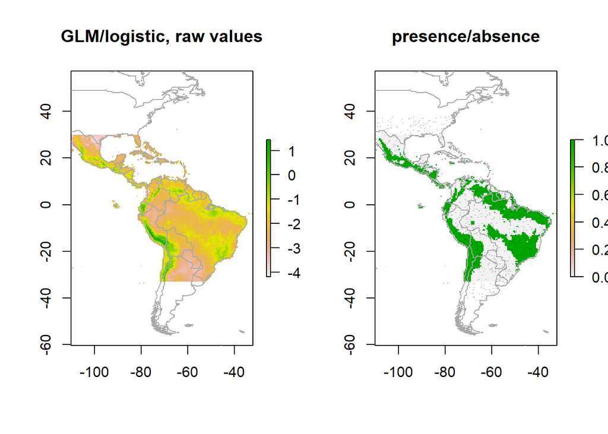

```r
#Predecimos la distribución con el primer modelo
pg1 <- predict(predictors, gm1, ext=ext)
pg2 <- predict(predictors, gm2, ext=ext)
#Graficamos
par(mfrow=c(1,2))
plot(pg1, main='GLM/logistic, raw values')
plot(wrld_simpl, add=TRUE, border='dark grey')
tr <- threshold(ge1, 'spec_sens')
plot(pg1 > tr, main='presence/absence')
plot(wrld_simpl, add=TRUE, border='dark grey')
points(pres_train, pch='+')
points(backg_train, pch='-', cex=0.25)
```

### 2.5.4 Modelos de aprendizaje automático

Dentro de los algoritmos de aprendizaje automatizado MaxEnt (abreviatura de “Entropía máxima”; Phillips et al., 2006) es el algoritmo SDM más utilizado. Maxent se encuentra implementado en Java pero puede ser ejecutado desde el paquete **dismo**. Si se encuentra con una versión de R superior a 3.5, Maxent no se encuentra disponible para esta versión. Sin embargo, puede descargar Maxent haciendo clic [aquí](http://biodiversityinformatics.amnh.org/open_source/maxent/). Una vez descargada esta versión vaya a la libreria de R, busque el paquete dismo y la carpeta java, copie y peque el ejecutable de maxent en esta carpeta. La dirección debería ser similar a esta “….R/win-library/3.5/dismo/java”

```r
#Cargamos maxent
maxent()
```

```
## This is MaxEnt version 3.4.1
```

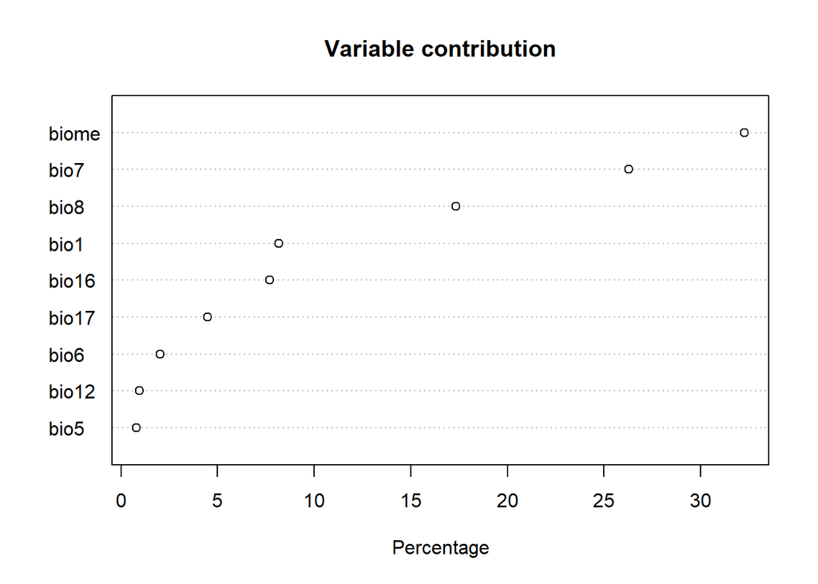

```r
#Ajustamos el modelo
#Es necesario informar a maxent las variables que se encuentran como factores
mx <- maxent(predictors, pres_train[,c("lon", "lat")], factors='biome')

#Graficamos las variables y su importancia
plot(mx)
```

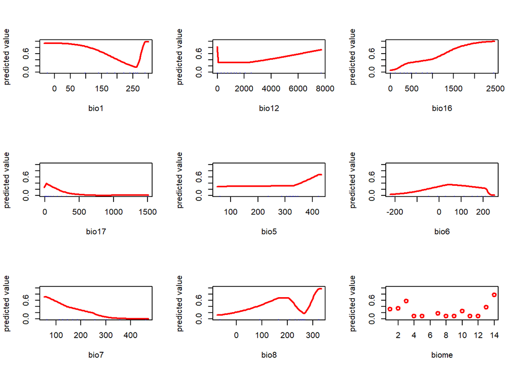

```r
response(mx)
```

```r
#Realizamos la evaluación del modelo
emx <- evaluate(pres_test[,c("lon", "lat")], backg_test[,c("lon", "lat")], mx, predictors)
emx
```

```
## class          : ModelEvaluation
## n presences    : 34
## n absences     : 200
## AUC            : 0.8197059
## cor            : 0.5213534
## max TPR+TNR at : 0.6323841
```

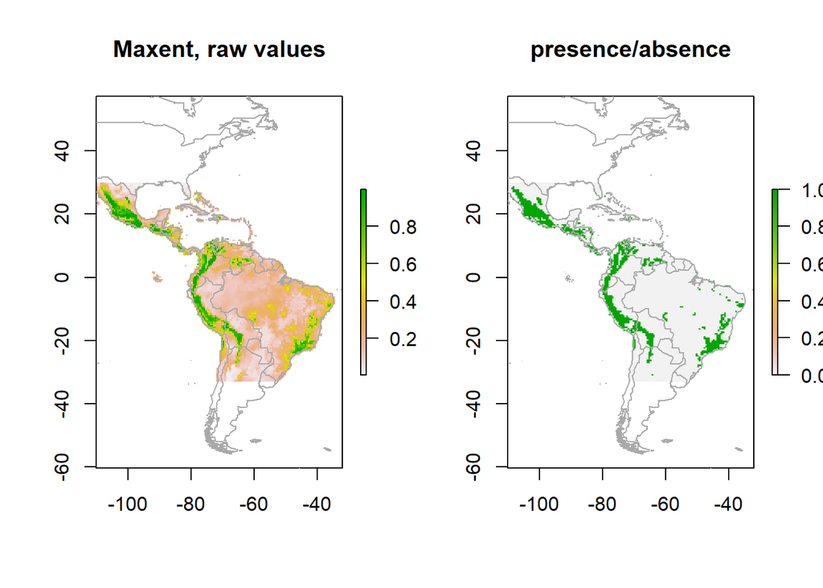

```r
#Predecimos
px <- predict(predictors, mx, ext=ext, progress='')

#Graficamos
par(mfrow=c(1,2))
plot(px, main='Maxent, raw values')
plot(wrld_simpl, add=TRUE, border='dark grey')
tr <- threshold(e, 'spec_sens')
plot(px > tr, main='presence/absence')
plot(wrld_simpl, add=TRUE, border='dark grey')
points(pres_train, pch='+')
```

Otro método que durante los últimos años se ha desarrollado es el método Random Forest (Breiman, 2001b), este es una extensión de los árboles de clasificación y regresión (CART; Breiman et al., 1984). En R se implementa en la función ‘randomForest’ en un paquete con el mismo nombre. La función randomForest puede tomar una fórmula o, en dos argumentos separados, un marco de datos con las variables predictoras y un vector con la respuesta. Si la variable de respuesta es un factor (categórico), randomForest hará una clasificación, de lo contrario hará una regresión. Mientras que con el modelo de distribución de especies a menudo estamos interesados en la clasificación (la especie está presente o no), el uso de la regresión proporciona mejores resultados. rf1 hace regresión, rf2 y rf3 hacen clasificación (son exactamente los mismos modelos). Consulte la función tuneRF para optimizar el procedimiento de ajuste del modelo.

```r
library(randomForest)
#Ajustamos el modelo
model <- pa ~ bio16 + bio5 + bio6 + bio17 + bio12
rf1 <- randomForest(model, data=envtrain)
model <- factor(pa) ~ bio16 + bio5 + bio6 + bio17 + bio12
rf2 <- randomForest(model, data=envtrain)
rf3 <- randomForest(envtrain[,1:8], factor(pb_train))

#Evaluamos el modelo usamos unicamente el primero
erf <- evaluate(testpres, testbackg, rf1)
erf
```

```
## class          : ModelEvaluation
## n presences    : 34
## n absences     : 200
## AUC            : 0.7736765
## cor            : 0.3843336
## max TPR+TNR at : 0.1684238
```

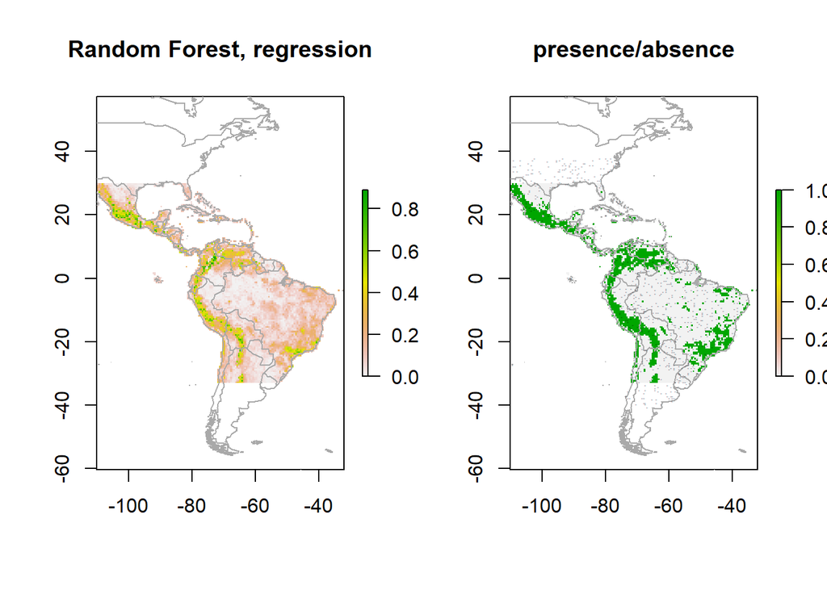

```r
#predecimos
pr <- predict(predictors, rf1, ext=ext)

#graficamos
par(mfrow=c(1,2))
plot(pr, main='Random Forest, regression')
plot(wrld_simpl, add=TRUE, border='dark grey')
tr <- threshold(erf, 'spec_sens')
plot(pr > tr, main='presence/absence')
plot(wrld_simpl, add=TRUE, border='dark grey')
points(pres_train, pch='+')
points(backg_train, pch='-', cex=0.25)
```

Support Vector Machines (SVMs; Vapnik, 1998) aplica un método lineal simple a los datos, pero en un espacio de características de alta dimensión no relacionado linealmente con el espacio de entrada, pero en la práctica, no implica ningún cálculo en esa alta dimensión del espacio. Esta simplicidad combinada con el rendimiento de vanguardia en muchos problemas de aprendizaje (clasificación, regresión y detección de novedad) ha contribuido a la popularidad de la SVM (Karatzoglou et al., 2006). Fueron utilizados por primera vez en modelos de distribución de especies por Guo et al. (2005). Existen varias implementaciones de svm en R. Las implementaciones más útiles en nuestro contexto son probablemente la función “ksvm” en el paquete “kernlab”.

```r
library(kernlab)
svm <- ksvm(pa ~ bio16 + bio5 + bio6 + bio17 + bio12, data=envtrain)
esv <- evaluate(testpres, testbackg, svm)
esv
```

```
## class          : ModelEvaluation
## n presences    : 34
## n absences     : 200
## AUC            : 0.7601471
## cor            : 0.3232351
## max TPR+TNR at : 0.03340697
```

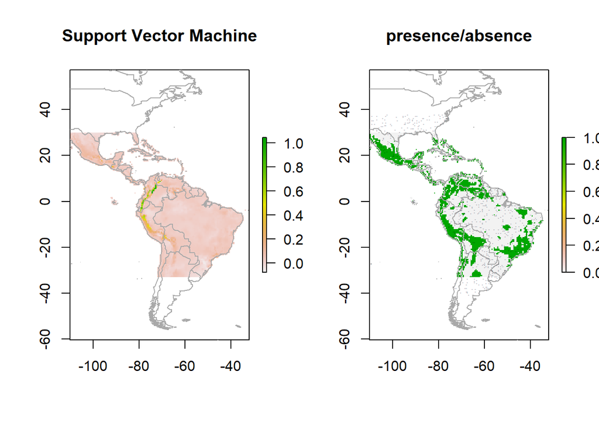

```r
#Hacemos la predicción
ps <- predict(predictors, svm, ext=ext)

#Graficamos
par(mfrow=c(1,2))
plot(ps, main='Support Vector Machine')
plot(wrld_simpl, add=TRUE, border='dark grey')
tr <- threshold(esv, 'spec_sens')
plot(ps > tr, main='presence/absence')
plot(wrld_simpl, add=TRUE, border='dark grey')
points(pres_train, pch='+')
points(backg_train, pch='-', cex=0.25)
```

## 2.6 Combinando predicciones del modelo

En lugar de confiar en un solo “mejor” modelo, algunos autores (por ejemplo, Thuillier, 2003) han abogado por utilizar muchos modelos y aplicar algún tipo de promedio de modelos. Vea el paquete biomod2 para una implementación. Por supuesto, puede implementar estos enfoques usted mismo. A continuación se muestra un ejemplo muy breve. Primero hacemos un RasterStack de nuestras predicciones de modelos individuales:

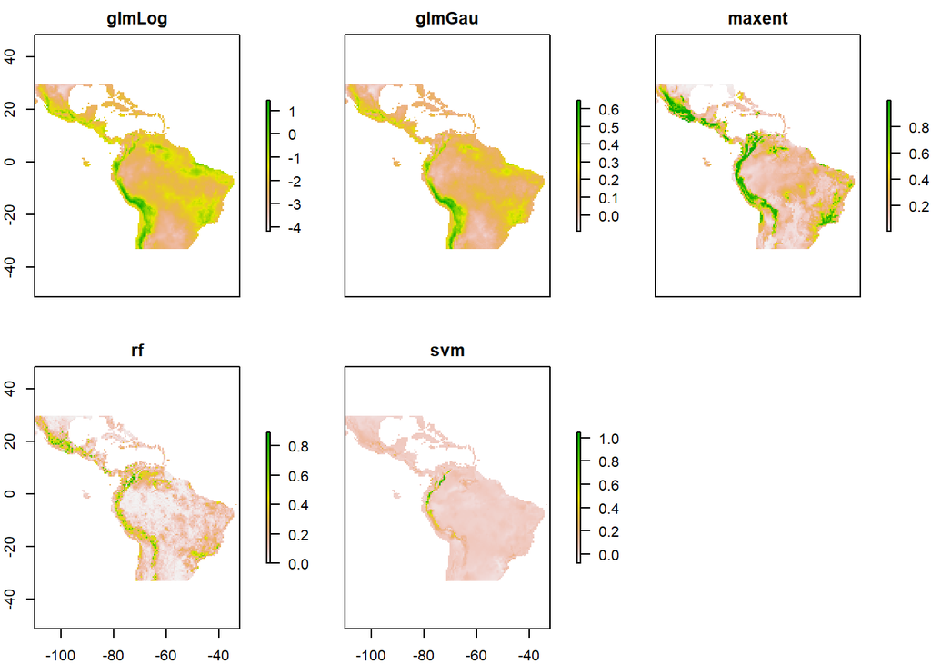

```r
#modelos con AUC mayor a 0.70
models <- stack( pg1, pg2,px,pr,ps)
names(models) <- c("glmLog","glmGau", "maxent", "rf", "svm")
plot(models)
```

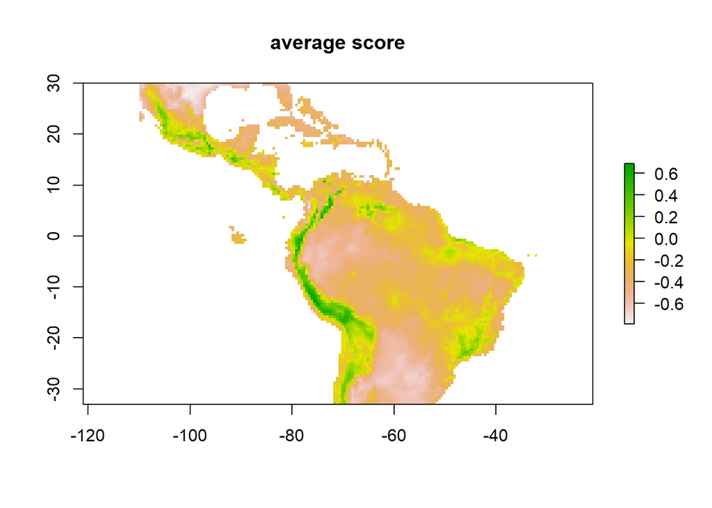

```r
#Calculamos la media
m <- mean(models)
plot(m, main='average score')
```

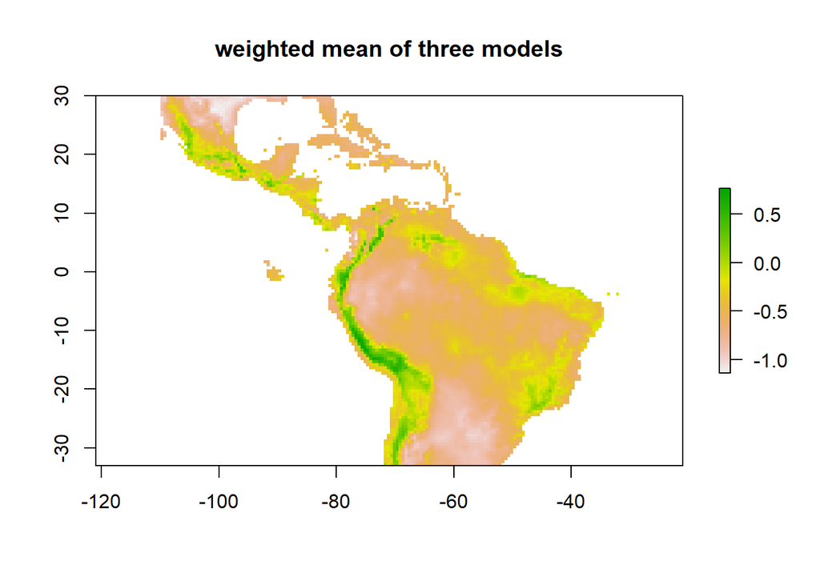

```r
#como una media pesada por el AUC

auc <- sapply(list(emx,ge1, ge2, erf, esv), function(x) x@auc)
w <- (auc-0.5)^2
m2 <- weighted.mean( models, w)
plot(m2, main='weighted mean of three models')
```